# Econometría Aplicada con R

Sesión 02: Modelo de regresión lineal múltiple

Javier Emmanuel Anguiano Pita

SECIHTI-Universidad de Guadalajara

16 de junio de 2026

## Agenda del día

1. **El modelo de regresión lineal**
   - Motivación
   - MCO como estimador óptimo
   - Supuestos del modelo de MCO
2. **Estimación de regresiones en R**
   - Interpretación de la tabla de resultados
   - Criterios de bondad de ajuste
3. **Violación de supuestos clásicos**
   - Normalidad
   - Autocorrelación
   - Heterocedasticidad

# Introducción

## ¿De dónde viene el término “regresión”? (I)

**Francis Galton (1886)**

- Estudió la relación entre la estatura de padres e hijos
- Observó que los hijos de padres muy altos tendían a ser **más bajos que sus padres**
- Acuñó el término **“regresión a la media (mediocridad)”**

**Nota**

La regresión nació como un problema **biológico**, no económico. Su generalización a otras disciplinas vino después.

[figure not shown]

Francis Galton (1822-1911)

## Regresión a la “mediocridad”

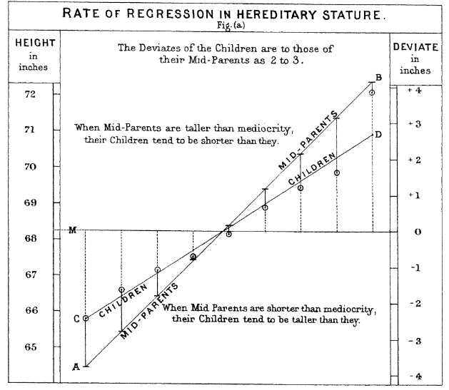

## ¿De dónde viene el término “regresión”? (II)

**Karl Pearson (1896)**

- Formalizó matemáticamente las ideas de Galton
- Sentó las bases del análisis de regresión moderno:
  - Desarrolló el **coeficiente de correlación** ($\rho$)
  - Idea de distribución muestral
  - Formalizó la prueba de hipótesis $\chi^2$
- Yule (1897) fue el primero en aplicar la regresión a datos socioeconómicos

## Análisis de Regresión

El análisis de regresión puede entenderse desde dos perspectivas complementarias:

**1. Ajuste de curva**

Encontrar la línea que **minimiza la distancia** entre los valores observados y los valores pronosticados por el modelo.

$$\min \sum_{i=1}^{n} e_i^2 = \min \sum_{i=1}^{n} (y_i - \hat{y}_i)^2$$

**2. Inferencia estadística**

Estimar los parámetros de un **proceso generador de datos (DGP)** y hacer inferencia sobre la población.

$$y_i = \beta_0 + \beta_1 x_i + \varepsilon_i$$

**Tip**

En econometría nos interesa principalmente la segunda perspectiva: no solo ajustar, sino **inferir y predecir**.

## Parámetros vs. Estimadores

### 🌎 Población

### (Desconocida)

$$y_i = \beta_0 + \beta_1 x_i + \varepsilon_i$$

- $\beta_0$, $\beta_1$ son **parámetros**
- Son valores **fijos** pero **desconocidos**
- Describen la relación **verdadera** en la población
- **Nunca los observamos**

### 🔬 Muestra

### (Observable)

$$\hat{y}_i = \hat{\beta}_0 + \hat{\beta}_1 x_i$$

- $\hat{\beta}_0$, $\hat{\beta}_1$ son **estimadores**
- Cambian con cada muestra
- Son nuestra **mejor aproximación** a los parámetros
- Los calculamos con MCO

**Importante**

En ciencias sociales trabajamos con la **mejor estimación** posible con los datos disponibles. ¡No son los parámetros **verdaderos** ⚠️!

## Correlación vs. Regresión

**Correlación**

- Mide la **fuerza y dirección** de la relación lineal entre dos variables
- Es **simétrica**: $r(X,Y) = r(Y,X)$
- No distingue entre causa y efecto
- Rango: $-1 \leq r \leq 1$

**Regresión**

- Modela cómo **una variable depende** de otra(s)
- Es **asimétrica**: $Y$ depende de $X$, no al revés
- Permite hacer **predicciones**
- Cuantifica el **efecto marginal** de $X$ sobre $Y$

**Advertencia**

Una correlación alta entre $X$ y $Y$ **no implica** que $X$ cause $Y$.

## Correlación no es causalidad

| Variable X | Variable Y | Correlación | ¿Causalidad? |
| --- | --- | --- | --- |
| Ventas de helado | Personas ahogadas | Alta positiva | ❌ Ambas aumentan en verano |
| Número de bomberos | Daño del incendio | Alta positiva | ❌ Los incendios grandes atraen más bomberos |
| Años de educación | Ingresos | Alta positiva | ¿? Puede haber variables omitidas |

**El problema:** dos variables pueden moverse juntas por:

- Una **causa común** (variable confusora)
- **Causalidad inversa** (Y causa X, no al revés)
- **Coincidencia** (correlaciones espurias)

**Tip**

La regresión por sí sola **no resuelve** el problema de causalidad. Se necesitan supuestos adicionales o diseños específicos.

## Causalidad en economía

En economía, establecer causalidad es difícil porque **no podemos hacer experimentos controlados** en la mayoría de los casos.

**El problema fundamental de la causalidad:**

Para saber el efecto causal de $X$ sobre $Y$ necesitaríamos observar a la misma unidad **con y sin** el tratamiento simultáneamente. Eso es imposible.

| Estrategia | Idea central |
| --- | --- |
| Experimento aleatorio (RCT) | Asignación aleatoria elimina sesgos |
| Variables instrumentales (IV) | Usar variación exógena en $X$ |
| Diferencias en diferencias (DiD) | Comparar cambios antes/después |
| Regresión discontinua (RD) | Explotar umbrales arbitrarios |

**Nota**

En este curso nos enfocamos en **MCO como herramienta descriptiva y predictiva**. La identificación causal es un tema de econometría avanzada.

## ¿Qué técnica elegir?

Existen más de 100 técnicas de estimación para modelos de regresión (MV, GMM, IV, LASSO, Ridge…). ¿Por qué usamos MCO?

**El Teorema de Gauss-Markov establece que MCO es el mejor estimador lineal insesgado (MELI-BLUE):**

| Propiedad | Significado |
| --- | --- |
| **M**ejor | Menor varianza entre todos los estimadores lineales insesgados |
| **E**stimador | Es un estimador, no el parámetro verdadero |
| **L**ineal | Es una función lineal de $Y$ |
| **I**nsesgado | $E(\hat{\beta}) = \beta$ en promedio acierta |

**Advertencia**

Estas propiedades se cumplen **únicamente si se satisfacen los supuestos clásicos** del modelo.

## Los supuestos clásicos de MCO

| # | Supuesto | Descripción |
| --- | --- | --- |
| 1 | **Linealidad** | El modelo es lineal en los parámetros |
| 2 | **Exogeneidad** | $E(\varepsilon_i \mid X) = 0$ |
| 3 | **Homocedasticidad** | $Var(\varepsilon_i) = \sigma^2$ constante |
| 4 | **No autocorrelación** | $Cov(\varepsilon_i, \varepsilon_j) = 0$ para $i \neq j$ |
| 5 | **Normalidad** | $\varepsilon_i \sim N(0, \sigma^2)$ |

**Importante**

La normalidad se asume sobre los **residuales** $\hat{e}_i$, no sobre las variables $Y$ o $X$.

## La normalidad: el menor de nuestros problemas

**¿Por qué no debería preocuparnos tanto?**

- Con muestras grandes el **Teorema del Límite Central (TLC)** garantiza que $\hat{\beta}$ se distribuye normalmente **sin importar** la distribución de $\varepsilon_i$
- La inferencia (p-values, IC) sigue siendo válida **asintóticamente**
- Los problemas **realmente graves** son:
  - Heterocedasticidad
  - Autocorrelación
  - Endogeneidad

**Tip**

Con $n > 30$ el TLC ya empieza a funcionar. Con $n > 100$ la normalidad es casi irrelevante.

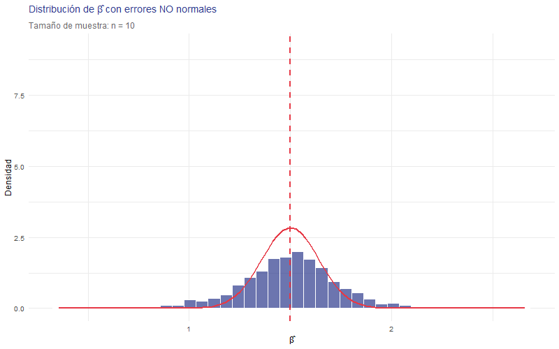

# Fin del primer bloque 🗣

# Estimación de modelos de regresión en `R`

## Estrategia para análisis de datos

1. Definir problema de investigación y variables de interés.
2. Recopilar los datos de fuentes oficiales.
3. Gráficar los datos para entenderlos.
4. Estimar coeficientes de correlación de Pearson y p-values
5. Estimar modelo de regresión.
6. Interpretación de coeficientes y bondad de ajuste del modelo.
7. Pruebas de validación del modelo.
8. Elaboración de tabla para informe de resultados.

## Problema de investigación

En este ejemplo vamos a estudiar los efectos del nivel de educación, la experiencia laboral y los años en la empresa actual sobre el nivel de salarios de un grupo de personas.

**Objetivos**:

1. Gráficar los datos en un diagrama de dispersión
2. Estimar coeficientes de correlación de Pearson ($\rho$)
3. Estimar modelo y validar supuestos

## Gráficas de dispersión en `R`

Existen diversas librerías y funciones. Aquí vamos a usar `pairs()`

**Sintáxis de uso**

```r
library(wooldridge)
data(wage1)

pairs(
  datos,
  labels = c("X1", "X2", "..", "Xn")
)
```

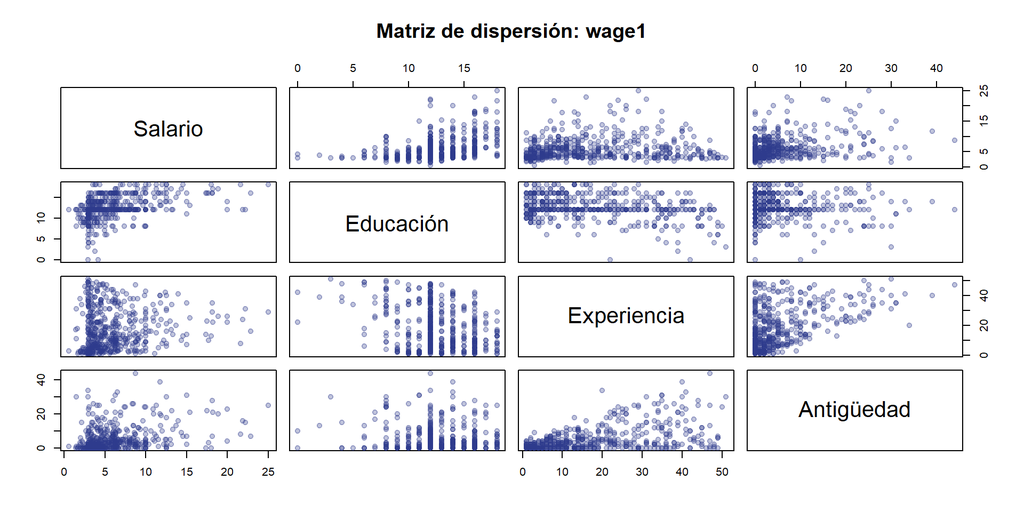

## Estadística descriptiva

En este curso vamos a utilizar la librería `modelsummary` para calcular estadística descriptiva y dar formato a nuestras tablas de resultados.

**Sintáxis de uso**

```r
# install.packages("modelsummary)
library(modelsummary)

datasummary(
  All(datos) ~ Mean + SD + Min + Max + N,
  data = datos,
  output = "gt"
)
```

`All()` selecciona automáticamente todas las columnas con datos **numéricos**.

## Coeficientes de correlación de Pearson

Aquí vamos a utilizar la librería `correlation`

**Sintáxis de uso**

```r
# install.packages("correlation")
library(correlation)

correlation(
  datos,
  method = "pearson"
)
```

```
# Correlation Matrix (pearson-method)

Parameter1 | Parameter2 |     r |         95% CI | t(524) |         p
---------------------------------------------------------------------
wage       |       educ |  0.41 | [ 0.33,  0.47] |  10.17 | < .001***
wage       |      exper |  0.11 | [ 0.03,  0.20] |   2.60 | 0.019*
wage       |     tenure |  0.35 | [ 0.27,  0.42] |   8.47 | < .001***
educ       |      exper | -0.30 | [-0.38, -0.22] |  -7.19 | < .001***
educ       |     tenure | -0.06 | [-0.14,  0.03] |  -1.29 | 0.198
exper      |     tenure |  0.50 | [ 0.43,  0.56] |  13.19 | < .001***

p-value adjustment method: Holm (1979)
Observations: 526
```

## Estimando una regresión en R

La función `lm()` (*linear model*) es la función base de R para estimar modelos de regresión por MCO:

```r
# Sintaxis básica
modelo <- lm(y ~ x1 + x2 + x3, data = datos)
```

**Estructura de la fórmula:**

| Símbolo | Significado | Ejemplo |
| --- | --- | --- |
| `~` | “en función de” | `y ~ x` |
| `+` | agregar variable | `y ~ x1 + x2` |
| `-1` | quitar intercepto | `y ~ x - 1` |
| `*` | interacción completa | `y ~ x1 * x2` |
| `I()` | transformación | `y ~ I(x^2)` |

## Ejercicio práctico

Estimemos el siguiente modelo de regresión:

$$wage_{i} = \beta_{0} + \beta_{1} \cdot educ_{i} + \beta_{2} exper_{i} + \beta_{3} tenure + \varepsilon_{i}$$

```r
library(wooldridge)

# 1. Cargar datos
data(wage1, package = "wooldridge")

# 2. Estimar el modelo
modelo <- lm(wage ~ educ + exper + tenure, data = wage1)

# 3. Ver resultados
summary(modelo)

# 4. Extraer componentes específicos
coef(modelo)        # coeficientes
residuals(modelo)   # residuales
fitted(modelo)      # valores ajustados
confint(modelo)     # intervalos de confianza
```

## ¿Qué nos dice cada parte?

**Coeficientes**

- `Estimate`: efecto marginal de $X$ sobre $Y$
- `Std. Error`: precisión del estimador
- `t value`: $\hat{\beta} / SE(\hat{\beta})$
- `Pr(>|t|)`: p-value de la prueba $H_0: \beta = 0$

**Códigos de significancia**

- `***` $p < 0.001$
- `**` $p < 0.01$
- `*` $p < 0.05$
- `.` $p < 0.10$

**Estadísticos globales**

- `Residual standard error`: $\hat{\sigma}$, dispersión de los residuales
- `Multiple R-squared`: $R^2$, bondad de ajuste
- `Adjusted R-squared`: $R^2$ ajustado por número de variables
- `F-statistic`: prueba de significancia conjunta $H_0: \beta_1 = \beta_2 = ... = \beta_k = 0$
- `p-value`: Asociado a la prueba de Wald (F)

## Interpretación de los coeficientes

Para el modelo:
$$\widehat{wage} = -2.87 + 0.60 \cdot educ + 0.02 \cdot exper + 0.17 \cdot tenure$$

**Intercepto** ($\hat{\beta}_0 = -2.87$):

Valor esperado de $Y$ cuando **todas** las variables independientes son cero. En muchos casos no tiene interpretación económica directa.

Manteniendo $exper$ y $tenure$ (años en la empresa actual) constantes, un año adicional de educación se asocia con un incremento de **$0.60 dólares por hora** en el salario.

**Advertencia**

MCO estima **asociaciones**, no efectos causales. La interpretación causal requiere supuestos adicionales.

## Pruebas de hipótesis

Cuando estimamos un modelo de regresión nos interesan dos pruebas de hipótesis:

**1. Significancia individual:**

$$H_{0}: \beta_{i} = 0$$
$$H_{1}: \beta_i \neq 0$$
$$t_{stat} = \frac{\hat{\beta}_{i}}{SE(\hat{\beta}_i)}$$

**2. Significancia conjunta:**

$$H_0: \beta_1 = \beta_2 = ... = \beta_k = 0$$
$$H_1: \text{al menos un } \beta_j \neq 0$$
$$F_{k,\,n-k-1} = \frac{R^2/k}{(1-R^2)/(n-k-1)}$$

## El coeficiente de determinación $R^2$

$$R^2 = \frac{SSR}{SST} = 1 - \frac{SSE}{SST}$$

**Descomposición de la varianza:**

- $SST = \sum(y_i - \bar{y})^2$: varianza **total** de $Y$
- $SSR = \sum(\hat{y}_i - \bar{y})^2$: varianza **explicada** por el modelo
- $SSE = \sum(e_i)^2$: varianza **no explicada** (residuales)

**Interpretación:**

- Rango: $0 \leq R^2 \leq 1$
- Mide la proporción de la **varianza de** $Y$ explicada por el modelo
- $R^2 = 0.31$ significa que el modelo explica el **31% de la variación** en los salarios

**Importante**

Un $R^2$ alto **no garantiza** un buen modelo. Un $R^2$ bajo **no invalida** el modelo. Lo que importa es la correcta especificación y el cumplimiento de los supuestos.

## Modelo alternativo

Estimemos el siguiento modelo que utiliza la variable dependiente expresada en términos de logaritmos naturales:

$$\ln wage_{i} = \beta_{0} + \beta_{1} \cdot educ_{i} + \beta_{2} exper_{i} + \beta_{3} tenure + \varepsilon_{i}$$

**Advertencia**

La nueva forma funcional cambia la interpretación de las $\beta$’s. Ahora explican cambios unitarios y respuestas porcentuales en la variable dependiente.

## $R^2$ vs. $R^2$ ajustado

$R^2$ ordinario

$$R^2 = 1 - \frac{SSE}{SST}$$

- **Siempre aumenta** al agregar variables
- No penaliza la complejidad del modelo
- Puede llevar a **sobreajuste**

$R^2$ ajustado

$$\bar{R}^2 = 1 - \frac{SSE/(n-k-1)}{SST/(n-1)}$$

- **Penaliza** por el número de variables $k$
- Puede **disminuir** al agregar variables irrelevantes
- Más adecuado para **comparar modelos**

**Tip**

Usa $\bar{R}^2$ cuando compares modelos con diferente número de variables explicativas.

## Criterios de información

Para comparar modelos que **no son anidados** usamos criterios de información que penalizan la complejidad:

| Criterio | Fórmula | Penalización |
| --- | --- | --- |
| **AIC** | $-2\ell + 2k$ | Moderada |
| **BIC** | $-2\ell + k\ln(n)$ | Más severa para $n$ grande |

Donde $\ell = -\frac{n}{2}\ln(2\pi) - \frac{n}{2}\ln(\hat{\sigma}^2) - \frac{SSE}{2\hat{\sigma}^2}$, $k$ es el número de parámetros estimados y $n$ el tamaño de muestra.

**Regla de decisión:**

- El modelo con **menor** AIC o BIC es preferible
- No existe un umbral absoluto: son medidas **relativas**
- BIC tiende a seleccionar modelos más **parsimoniosos**

```r
# En R: para modelos lm() R recupera ell a partir de los residuales
AIC(modelo)
BIC(modelo)
logLik(modelo) # para ver la log-verosimilitud directamente
```

# Fin del segundo bloque 🗣

# Validación de supuestos del modelo de regresión

## ¿Por qué validar los supuestos?

Si los supuestos de MCO se violan:

- Los estimadores $\hat{\beta}$ pueden ser **sesgados** o **ineficientes**
- Los errores estándar son **incorrectos**
- Los p-values y los intervalos de confianza son **inválidos**
- Las conclusiones de la investigación pueden ser **erróneas**

**Tip**

Siempre empieza con el diagnóstico visual antes de las pruebas formales. Los gráficos te dan intuición sobre qué buscar.

## Normalidad de los residuales

## Pruebas de normalidad

**¿Qué evaluamos?**

$$\varepsilon_i \sim N(0, \sigma^2)$$

**Prueba de Jarque-Bera**

Evalúa si los residuales tienen la asimetría y curtosis de una distribución normal:

$$JB = \frac{n}{6}\left(S^2 + \frac{(K-3)^2}{4}\right)$$

$$H_0: \text{residuales normales}$$
$$JB \sim \chi^2(2)$$

**Prueba Shapiro-Wilk**

Evalúa qué tan parecida es la distribución de los residuales a una distribución normal

$$W = \frac{(\sum_{i}^{n}a_{i}x_{(i)}^2)}{\sum_{i=1}^{n}(x_{i}-\bar{x})}$$

$$H_0: \text{Normalidad}$$
$$\text{Simulaciones}$$

## ¿Qué supone la no-normalidad para MCO?

- La normalidad de los residuales no afecta las propiedades de los estimadores:
  - Insesgados
  - Consistentes (¿Qué significa?)
- Por lo tanto:
  - Los intervalos de confianza siguen siendo asintóticamente válidos.
  - Las pruebas t y F suelen funcionar bien
  - En muestras pequeñas se pierde precisión de los SE.

**Advertencia**

⚠️ Cuando se usan muestras pequeñas (n<40) suelen existir problemas de precisión. Podemos argumentar TLC.

# Heterocedasticidad

## Descripción del problema

**¿Qué evaluamos?**
$$Var(\varepsilon_i|X_i) = \sigma^2 \quad \text{(constante para todo } i\text{)}$$

**Causas:**

- Heterogeneidad entre individuos.
- Variables omitidas.
- Forma funcional incorrecta.
- Diferencias de escala entre observaciones.
- Valores **atípicos**.

**Consecuencias:**

- Los coeficientes de MCO son insesgados.
- No son eficientes.
- Los errores estándar son incorrectos.
- La inferencia estadística pierde validez.

## Diagnóstico visual

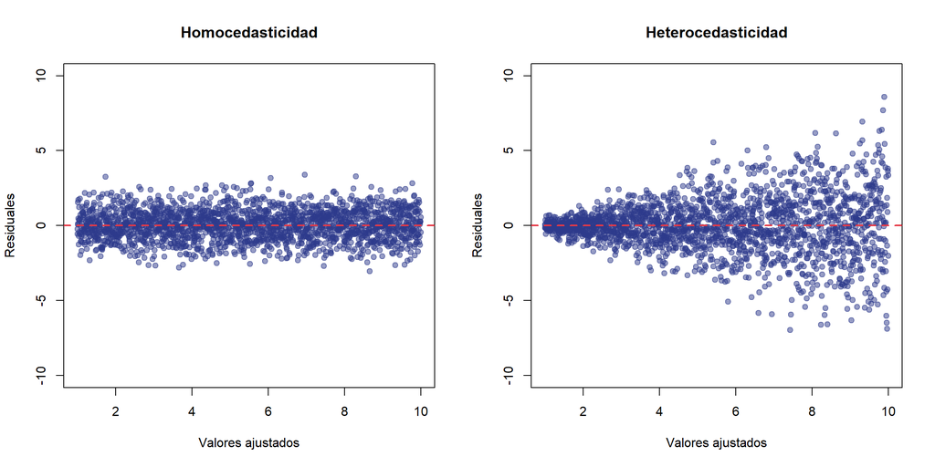

## Prueba de Breusch-Pagan (1979)

Se utiliza para detectar heterocedasticidad en los residuales de la regresión.

$$H_0:Var(u_i) = \sigma^{2}$$
$$H_1:Var(u_i) \neq \sigma^2$$
**1. Procedimiento**

Se estiman los residuales $\hat{u_i}$ del modelo original y luego:
$$\hat{u_{i}}^{2} = \alpha_0 + \alpha_1 X_{1i} + ... + a_{k}X_{ki} + v_{i}$$

$X_{ki}$ son los las variables independientes de la regresión.

## Prueba de Breusch-Pagan (1979)

$$H_0: \alpha_1 = \alpha_2 = ... = \alpha_k = 0 \text{ (Homocedasticidad)}$$
$$H_1: \exists \alpha_j \neq 0 \text{ (Heterocedasticidad)}$$
**2. Estadístico de prueba**

$$LM = n\times R^2$$
donde $R^2$ se obtiene de la regresión auxiliar

$$LM \sim \chi^2(k)$$
Donde *k* es el número de X’s en el modelo original.

## Prueba de heterocedasticidad en R

Para estimar la prueba de Breusch-Pagan, necesitamos instalar y cargar la librería `lmtest`

```r
library(lmtest)
modelo <- lm(y ~ x1 + x2 + x3, data = datos)

bptest(modelo)
```

La prueba por defecto realiza la versión *studentizada* de Koenker-Basset (1982), que es más robusta cuando los residuales de la regresión **no son normales**.

## Corrección del problema de heterocedasticidad

**1. Errores estándar robustos (White o Newey-West)**

- Mantienen los coeficientes de MCO.
- Corrigen la estimación de los errores estándar de $\hat{\beta}$’s.

**2. Transformación de las variables**

- Uso de logaritmos naturales.
- Expresar variables en tasas o proporciones.

**3. Mínimos cuadrados ponderados (WLS)**

- Requiere conocer la forma/estructura de la heterocedasticidad.
- Asigna menor peso a observaciones con mayor varianza.

# Autocorrelación

## Pruebas de autocorrelación serial

**¿Qué evaluamos?**

$$Cov(\varepsilon_i, \varepsilon_j) = 0 \quad \text{para } i \neq j$$

**¿Por qué es un problema?**

- Si $E(u_i \mid X) = 0$, los coeficientes siguen siendo **insesgados**
- Los coeficientes **NO** son eficientes
- Los errores estándar son **incorrectos**
- La inferencia estadística **no es válida** 😥

**¿Por qué puede existir?**

- Variables omitidas
- Dinámica o inercia temporal
- Tendencias o ciclos no modelados
- Especificación incorrecta

## Prueba de Breusch-Godfrey (1979) I

**¿Qué evalúa?**

Contrasta si los residuos están correlacionados entre sí hasta el orden $p$.

$$H_0: \rho_1 = \rho_2 = \cdots = \rho_p = 0$$
$$H_1: \rho_j \neq 0 \quad \text{para algún } j$$

**Ventajas de la prueba:**

- Detecta autocorrelación de **cualquier orden**
- Funciona con **variables rezagadas** entre los regresores
- Es general y más flexible que D-W.

**Advertencia**

⚠️ La prueba es muy sensible al número de rezagos incluidos en la regresión auxiliar.

## Prueba de Breusch-Godfrey (1979) II

**Estadístico de prueba**

Se estima la siguiente regresión auxiliar sobre los residuales:

$$\hat{u}_t = \alpha + X_t\beta + \rho_1\hat{u}_{t-1} + \cdots + \rho_p\hat{u}_{t-p} + v_t$$

A partir del $R^2$ de esta regresión se calcula:

$$LM = nR^2 \sim \chi^2(p)$$

Donde $p$ es el número de rezagos incluidos.

```r
library(lmtest)

# Prueba de Breusch-Godfrey con 2 rezagos
bgtest(modelo, order = 2)
```

## Corrección del problema de autocorrelación

**1. Errores estándar de Newey-West (HAC)**

- Robustos a heterocedasticidad y autocorrelación simultáneamente.
- Mantienen los coeficientes de MCO sin cambios.
- Corrigen la estimación de los errores estándar de los $\hat{\beta}$’s.

**2. Mínimos cuadrados generalizados factibles (FGLS)**

- Transforma el modelo para eliminar la autocorrelación.
- Requiere especificar la estructura de correlación (p.ej. AR(1)).
- Produce estimadores más eficientes que MCO si la estructura es correcta.

**3. Incluir variables rezagadas**

- Agrega $y_{t-1}$ o $x_{t-1}$ como regresores.
- Captura la dinámica temporal directamente en el modelo.
- Común en modelos de series de tiempo.

## ¿Qué hacen los errores de Newey-West (1987)?

Los estimadores `sandwich` sustituyen $\sigma^2I$ por una matriz más general:

$$\widehat{Var}(\hat{\beta}) = (X'X)^{-1}\hat{\Omega}(X'X)^{-1}$$
donde $\hat{\Omega}$ se construye a partir de los residuales de la regresión.

Los estimadores de Newey-West estiman:

- Las varianzas individuales ($\hat{u^2}$)
- Las co-varianzas ($\hat{u}_i, \hat{u}_j$)

# Fin de la sesión 🕺🏿